# Abbildungen für Version 4.0

## Teil 2: Neue Abbildungen

**references_int.png**

PlatzierungKap 3, „Referenzen“ direkt nach dem Beispiel `b += 10`

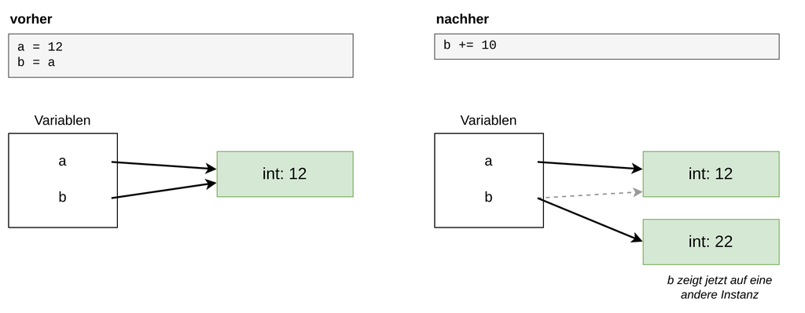

**Bildunterschrift:** Bei `b += 10` entsteht eine neue int-Instanz. Nur `b` zeigt danach auf sie, `a` bleibt unverändert.

**references_list.png**

PlatzierungKap 3, „Seiteneffekte“ nach `your_shopping_list.append('shoes')`

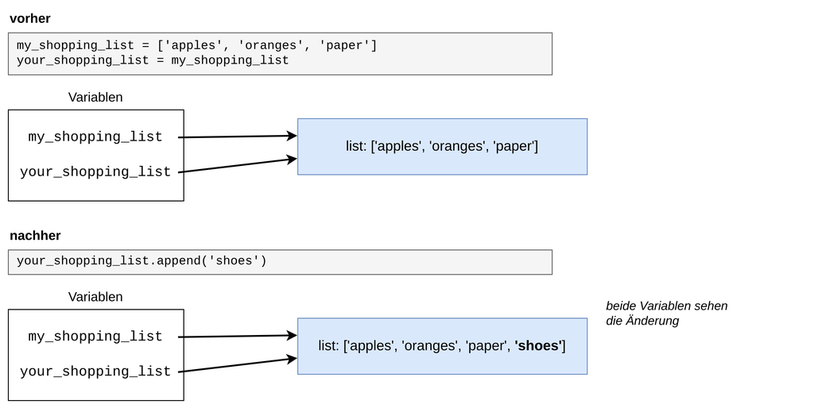

**Bildunterschrift:** Beide Variablen referenzieren dieselbe Liste. Eine Änderung über `your_shopping_list` ist deshalb auch über `my_shopping_list` sichtbar (Seiteneffekt).

**slicing.png**

PlatzierungKap 6, „Indexzugriff und List Slicing“ vor dem Slicing-Beispiel

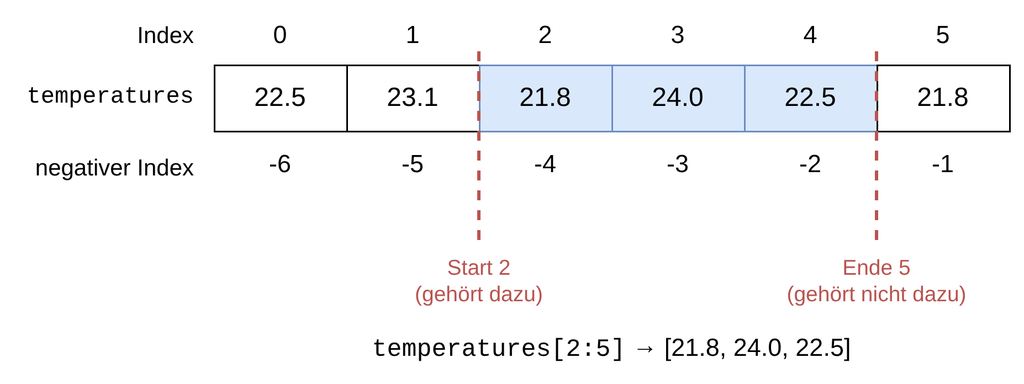

**Bildunterschrift:** Positive und negative Indizes der Liste `temperatures`. Beim Slicing gehört der Startindex dazu, der Endindex nicht.

**copy_shallow_deep.png**

PlatzierungKap 6, „Sicheres Kopieren von Listen“ nach dem deepcopy-Beispiel

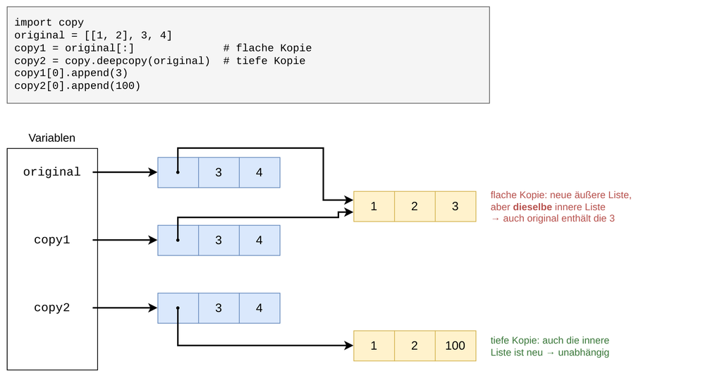

**Bildunterschrift:** Flache Kopie: Die äußere Liste ist neu, die innere Liste wird aber geteilt. Tiefe Kopie: Auch die innere Liste wird kopiert.

**matrix_references.png**

PlatzierungKap 6, im Fallstrick-Kasten F5 nach „Richtig: …“

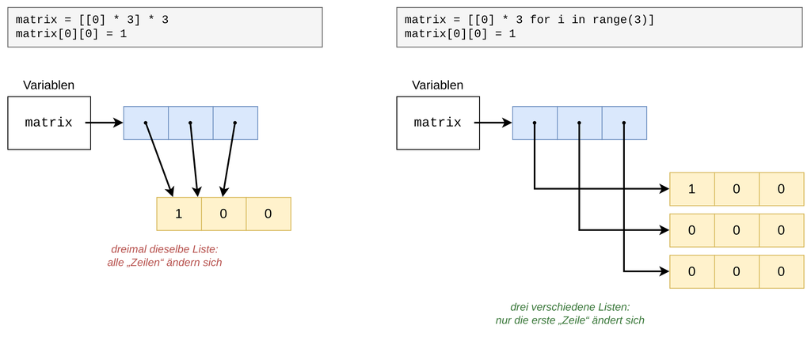

**Bildunterschrift:** Links: `* 3` vervielfältigt nur die Referenz auf eine einzige Zeile. Rechts: Die List Comprehension erzeugt drei verschiedene Listen.

**scope_legb.png**

PlatzierungKap 5, „Scope“ direkt nach der Erklärung der LEGB-Rule

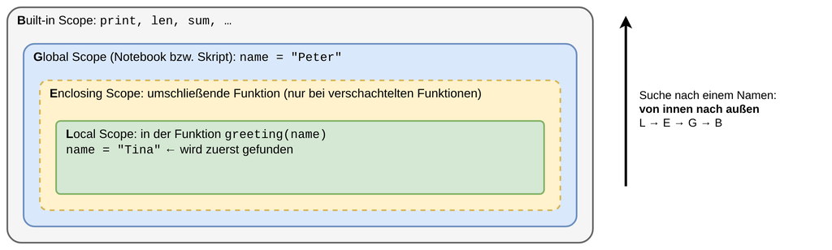

**Bildunterschrift:** Python sucht einen Namen von innen nach außen: Local → Enclosing → Global → Built-in. Im Beispiel wird das lokale `name = "Tina"` zuerst gefunden.